# Distribution of maximum of partial sums in Bernoulli trials

Evgeni Ovcharov

July 31, 2017

## Problem

Using Monte Carlo simulations, find the distribution of maximum in the sequence of partial sums associated with a randomly generated series of Bernoulli trials. The outcomes of the trials are the numbers -1 and 1, which occur with equal probability.

## Solution

The main parameters of the solution.

```r
outcomes = c(-1,1)
trials_length = 100
p_success = 0.5
N_trials = 1000
```

The function takes a series of Bernoulli trials called `flips` and returns the sequence of its partial sums.

```r
partial_sums = function(flips){

  sapply(1:length(flips), function(k) sum(flips[1:k]))
}
```

The function creates a series of Bernoulli trials of length $n$ with elements in the set `outcomes` and probability of success $p$. It then computes the associated sequence of partial sums and returns the position of the maximal partial sum. If the maximal partial sum occurs more than once, it selects one of its positions at random.

```r
trials = function(n = trials_length, p = p_success, sample_space = outcomes){

  flips = sample(sample_space, size = n, replace = TRUE, prob = c(1 - p, p))
  maxima = which(partial_sums(flips) == max(partial_sums(flips)), arr.ind = TRUE)
  if (length(maxima) == 1) return(maxima)
  else sample(maxima,1)
}
```

We visualise the results in a histogram.

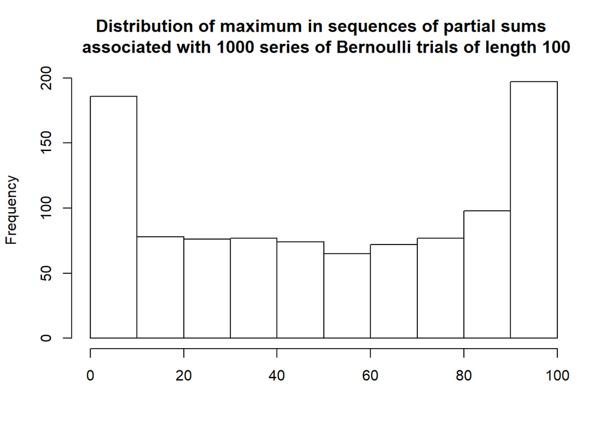

```r
hist(replicate(N_trials, trials()), xlab = "", main = paste0("Distribution of maximum in sequences of partial sums \n associated with ", N_trials, " series of Bernoulli trials of length ", trials_length))
```

The occurence of maximum with maximal probability at the two ends of the series may be viewed as counterintuitive. However, notice that if the probability is skewed towards the negative or positive outcome, then the maximum will occur with maximal probability in the begining or end of the series, respectively. So, the borderline case of `p = 0.5` may be seen as a compromise between the two. In the last diagram we show how sensitive the location of the maximum is to slight perturbations of `p` from the equilibrium position.

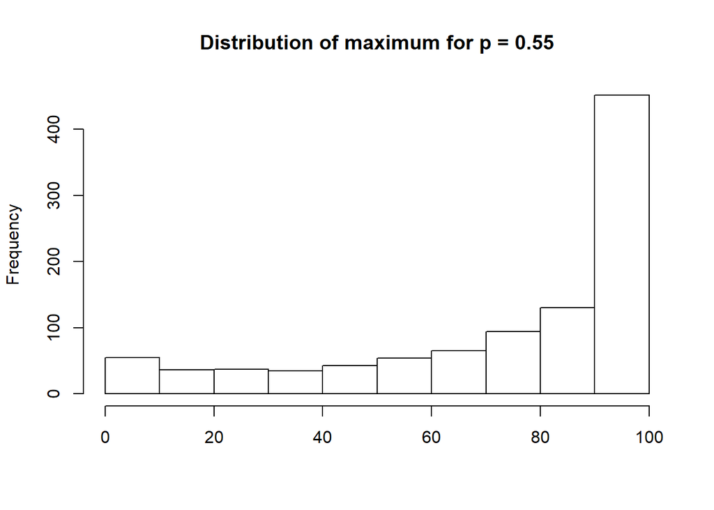